[figure not shown]

```python
from google.colab import drive
drive.mount('/content/drive')
```

# The Geo Dataframe

The geodataframe (GDF) is a dataframe (DF) where every row represents an spatial element (point, line, polygon).

The most common file type that stores spatial elements is the shapefile. Let's take a look at some of them:

1. In GitHub (cloud), create a repository named: introgeodf.
2. Clone that repo to a local folder in your computer.
3. In that local folder in your computer, create a folder named **maps**.
4. Go to **Paidea** and download three compressed files from the folder **WorldMaps**.

You may see something like this:

[figure not shown]

You can decompress those files:

[figure not shown]

Now, take a look a **World_Countries**:

[figure not shown]

There, you see that this **one map** requires **several files**. That is the nature of the shapefile.

Let's read the file with the help of **geopandas**:

```python
import os, geopandas as gpd

countries=gpd.read_file(os.path.join("maps","World_Countries","World_Countries.shp"))
```

Let's use some familiar DF functions:

```python
# what is it?
type(countries)
```

```
geopandas.geodataframe.GeoDataFrame
def __init__(data=None, *args, geometry=None, crs=None, **kwargs)
```

[output not shown]

```python
# dimensions
countries.shape
```

```
(252, 2)
```

```python
# names
countries.columns
```

```
Index(['COUNTRY', 'geometry'], dtype='object')
```

```python
# some content
countries.head()
```

|  | COUNTRY | geometry |
| --- | --- | --- |
| 0 | Aruba (Netherlands) | POLYGON ((-69.88223 12.41111, -69.94695 12.436... |
| 1 | Antigua and Barbuda | MULTIPOLYGON (((-61.73889 17.54055, -61.75195 ... |
| 2 | Afghanistan | POLYGON ((61.27656 35.60725, 61.29638 35.62853... |
| 3 | Algeria | POLYGON ((-5.15213 30.18047, -5.13917 30.19236... |
| 4 | Azerbaijan | MULTIPOLYGON (((46.54037 38.87559, 46.49554 38... |

```python
# what geometry?
countries.geom_type.unique()
```

```
array(['Polygon', 'MultiPolygon'], dtype=object)
```

```python
# any missing values?
countries[countries.isna().any(axis=1)]
```

|  | COUNTRY | geometry |
| --- | --- | --- |

```python
# types
countries.info()
```

```
<class 'geopandas.geodataframe.GeoDataFrame'>
RangeIndex: 252 entries, 0 to 251
Data columns (total 2 columns):
 #   Column    Non-Null Count  Dtype
---  ------    --------------  -----
 0   COUNTRY   252 non-null    object
 1   geometry  252 non-null    geometry
dtypes: geometry(1), object(1)
memory usage: 4.1+ KB
```

As you see, those pandas commands are working fine, but now we have a new column type: **geometry**. Let's see this map of countries:

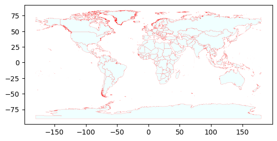

```python
countries.plot(facecolor="azure",#color of polygon fill
               edgecolor='red', #color of lines
               linewidth=0.1) #thickness of lines
```

Let's open the other maps:

```python
rivers=gpd.read_file(os.path.join("maps","World_Hydrography","World_Hydrography.shp"))
cities=gpd.read_file(os.path.join("maps","World_Cities","World_Cities.shp"))
```

```python
# what geo?
rivers.geom_type.unique(), cities.geom_type.unique()
```

```
(array(['LineString', 'MultiLineString'], dtype=object),
 array(['Point'], dtype=object))
```

This is the rivers map:

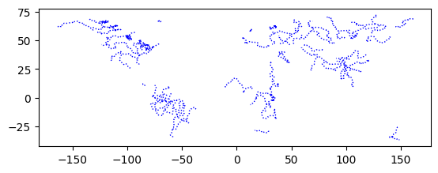

```python
rivers.plot(edgecolor='blue',
            linewidth=1,
            linestyle='dotted')
```

This is the cities map:

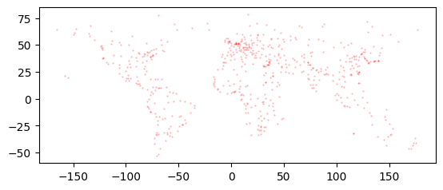

```python
cities.plot(marker='.', # marker type
            color='red',
            markersize=1,
            alpha=0.3) # transparency
```

You can start by creating the layer on the back (the base), and add layers on top:

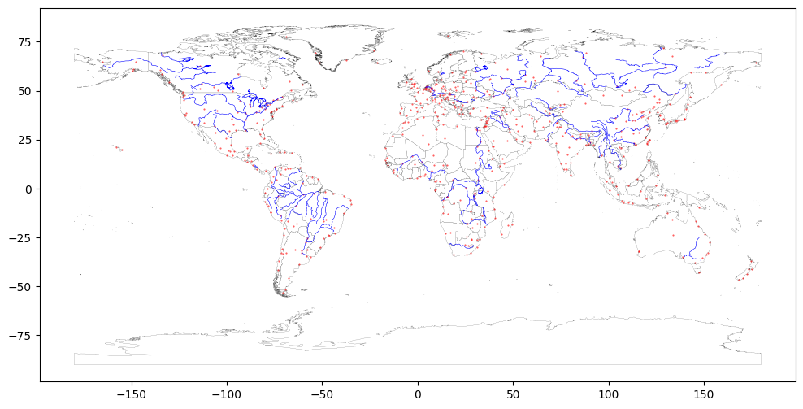

```python
base = countries.plot(facecolor="white",
                      edgecolor='black',
                      linewidth=0.1,
                      figsize=(12,12))

rivers.plot(edgecolor='blue', linewidth=0.4,
            ax=base)# on top of...
cities.plot(marker='.', color='red', markersize=1,alpha=0.7,
            ax=base) # on top of...
```

Saving into a different format (not shapefile):

```python
# ONE file - SEVERAL layers
import os

countries.to_file(os.path.join("maps","worldMaps.gpkg"), layer='countries', driver="GPKG")
rivers.to_file(os.path.join("maps","worldMaps.gpkg"), layer='rivers', driver="GPKG")
cities.to_file(os.path.join("maps","worldMaps.gpkg"), layer='cities', driver="GPKG")
```

# Map Projection

- shape
- area
- scale
- direction

Most maps come with a default CRS: 4326. Pay attention:

```python
Germany=countries[countries.COUNTRY=='Germany']
```

```python
Germany.crs
```

```
<Geographic 2D CRS: EPSG:4326>
Name: WGS 84
Axis Info [ellipsoidal]:
- Lat[north]: Geodetic latitude (degree)
- Lon[east]: Geodetic longitude (degree)
Area of Use:
- name: World.
- bounds: (-180.0, -90.0, 180.0, 90.0)
Datum: World Geodetic System 1984 ensemble
- Ellipsoid: WGS 84
- Prime Meridian: Greenwich
```

```python
# check units of measurement
Germany.crs.axis_info
```

```
[Axis(name=Geodetic latitude, abbrev=Lat, direction=north, unit_auth_code=EPSG, unit_code=9122, unit_name=degree),
 Axis(name=Geodetic longitude, abbrev=Lon, direction=east, unit_auth_code=EPSG, unit_code=9122, unit_name=degree)]
```

```python
# is this CRS projected?
Germany.crs.is_projected
```

```
False
```

Polygons have a centroid. When we try getting a centroid from an **unprojected** polygon, you get:

```python
# centroid
Germany.centroid
```

|  | 0 |
| --- | --- |
| 87 | POINT (10.39365 51.10656) |

**dtype:** geometry

## Reprojecting

A projected CRS will have units in meters or feet (or similar). You can request a crs per country [here](https://epsg.io/?q=brazil+kind%3APROJCRS):

```python
# recommended for Germany (meters)
Germany.to_crs(25832).crs.axis_info
```

```
[Axis(name=Easting, abbrev=E, direction=east, unit_auth_code=EPSG, unit_code=9001, unit_name=metre),
 Axis(name=Northing, abbrev=N, direction=north, unit_auth_code=EPSG, unit_code=9001, unit_name=metre)]
```

```python
# now this works with no warning
Germany.to_crs(25832).centroid
```

|  | 0 |
| --- | --- |
| 87 | POINT (596343.988 5656461.701) |

**dtype:** geometry

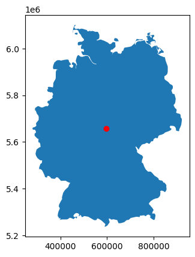

```python
# replotting:

base25832=Germany.to_crs(25832).plot()
Germany.to_crs(25832).centroid.plot(color='red',ax=base25832)
```

Let's keep the projected version for all our maps:

```python
cities_Germany_25832=cities[cities.COUNTRY=='Germany'].to_crs(25832)
```

```python
riversGermany_clipped=gpd.clip(rivers,Germany)
```

```python
Germany_25832=Germany.to_crs(25832)

rivers_Germany_25832=riversGermany_clipped.to_crs(Germany_25832.crs)
```

```python
## saving


import os

Germany_25832.to_file(os.path.join("maps","GermanyMaps_25832.gpkg"), layer='country', driver="GPKG")
cities_Germany_25832.to_file(os.path.join("maps","GermanyMaps_25832.gpkg"), layer='cities', driver="GPKG")
rivers_Germany_25832.to_file(os.path.join("maps","GermanyMaps_525832.gpkg"), layer='rivers', driver="GPKG")
#Germany_5243.centroid.to_file(os.path.join("maps","GermanyMaps_25832.gpkg"), layer='centroid', driver="GPKG")
```

### Exercise 1

1. Reproject your country's map layers.
2. Plot the reprojected layers
3. Save the reprojected layers as **gpkg**.

## Creating Spatial data

Let's open the **CSV**:

```python
import pandas as pd
infoairports=pd.read_csv(os.path.join("data","airports.csv"))

# some rows

infoairports.iloc[[0,1,2,3,-4,-3,-2,-1],:] #head and tail
```

|  | id | ident | type | name | latitude_deg | longitude_deg | elevation_ft | continent | iso_country | iso_region | municipality | scheduled_service | icao_code | iata_code | gps_code | local_code | home_link | wikipedia_link | keywords |
| --- | --- | --- | --- | --- | --- | --- | --- | --- | --- | --- | --- | --- | --- | --- | --- | --- | --- | --- | --- |
| 0 | 6523 | 00A | heliport | Total RF Heliport | 40.070985 | -74.933689 | 11.0 | NaN | US | US-PA | Bensalem | no | NaN | NaN | K00A | 00A | https://www.penndot.pa.gov/TravelInPA/airports... | NaN | NaN |
| 1 | 323361 | 00AA | small_airport | Aero B Ranch Airport | 38.704022 | -101.473911 | 3435.0 | NaN | US | US-KS | Leoti | no | NaN | NaN | 00AA | 00AA | NaN | NaN | NaN |
| 2 | 6524 | 00AK | small_airport | Lowell Field | 59.947733 | -151.692524 | 450.0 | NaN | US | US-AK | Anchor Point | no | NaN | NaN | 00AK | 00AK | NaN | NaN | NaN |
| 3 | 6525 | 00AL | small_airport | Epps Airpark | 34.864799 | -86.770302 | 820.0 | NaN | US | US-AL | Harvest | no | NaN | NaN | 00AL | 00AL | NaN | NaN | NaN |
| 83094 | 46378 | ZZ-0001 | heliport | Sealand Helipad | 51.894444 | 1.482500 | 40.0 | EU | GB | GB-ENG | Sealand | no | NaN | NaN | NaN | NaN | http://www.sealandgov.org/ | https://en.wikipedia.org/wiki/Principality_of_... | Roughs Tower Helipad |
| 83095 | 307326 | ZZ-0002 | small_airport | Glorioso Islands Airstrip | -11.584278 | 47.296389 | 11.0 | AF | TF | TF-U-A | Grande Glorieuse | no | NaN | NaN | NaN | NaN | NaN | NaN | NaN |
| 83096 | 346788 | ZZ-0003 | small_airport | Fainting Goat Airport | 32.110587 | -97.356312 | 690.0 | NaN | US | US-TX | Blum | no | NaN | NaN | 87TX | 87TX | NaN | NaN | NaN |
| 83097 | 313629 | ZZZZ | small_airport | Satsuma Iōjima Airport | 30.784722 | 130.270556 | 338.0 | AS | JP | JP-46 | Mishima | no | NaN | NaN | RJX7 | RJX7 | NaN | http://wikimapia.org/6705190/Satsuma-Iwo-jima-... | SATSUMA,IWOJIMA,RJX7 |

```python
infoairports['iso_country']
```

|  | iso_country |
| --- | --- |
| 0 | US |
| 1 | US |
| 2 | US |
| 3 | US |
| 4 | US |
| ... | ... |
| 83093 | CN |
| 83094 | GB |
| 83095 | TF |
| 83096 | US |
| 83097 | JP |

83098 rows × 1 columns

**dtype:** object

```python
infoairports = infoairports[infoairports['iso_country'] == 'DE']
```

This needs some cleaning:

```python
# bye first row
infoairports.reset_index(drop=True, inplace=True)
infoairports.drop(index=0,inplace=True)
infoairports.head()
```

|  | id | ident | type | name | latitude_deg | longitude_deg | elevation_ft | continent | iso_country | iso_region | municipality | scheduled_service | icao_code | iata_code | gps_code | local_code | home_link | wikipedia_link | keywords |
| --- | --- | --- | --- | --- | --- | --- | --- | --- | --- | --- | --- | --- | --- | --- | --- | --- | --- | --- | --- |
| 1 | 332693 | DE-0002 | closed | Ahlhorn Highway Strip | 52.929984 | 8.173538 | NaN | EU | DE | DE-NI | Großenkneten | no | NaN | NaN | NaN | NaN | NaN | NaN | Ahlhorn Autobahn-Notlandeplatz NLP |
| 2 | 299694 | DE-0003 | small_airport | August Euler Airfield | 49.853757 | 8.586243 | 358.0 | EU | DE | DE-HE | Griesheim | no | NaN | NaN | EDES | NaN | https://web.archive.org/web/20201019233127/htt... | https://en.wikipedia.org/wiki/Griesheim_Airport | ZCS, August-Euler Flugplatz, Griesheim Airport |
| 3 | 28576 | DE-0004 | small_airport | Gransee Airfield | 53.006280 | 13.202177 | 164.0 | EU | DE | DE-BR | Gransee | no | EDUG | NaN | NaN | NaN | http://www.gojump.de/ | https://de.wikipedia.org/wiki/Flugplatz_Gransee | NaN |
| 4 | 322973 | DE-0005 | small_airport | Warngau Airfield | 47.823990 | 11.703980 | 2380.0 | EU | DE | DE-BY | Warngau | no | NaN | NaN | NaN | NaN | http://www.fliegerclub-warngau.de | NaN | münchen, munich, wargau |
| 5 | 43128 | DE-0006 | small_airport | Locktow Airfield | 52.116500 | 12.709562 | 213.0 | EU | DE | DE-BR | Planetal | no | NaN | NaN | NaN | NaN | NaN | NaN | Sonderlandeplatz Locktow |

```python
# keep the  columns needed

infoairports.columns
```

```
Index(['id', 'ident', 'type', 'name', 'latitude_deg', 'longitude_deg',
       'elevation_ft', 'continent', 'iso_country', 'iso_region',
       'municipality', 'scheduled_service', 'icao_code', 'iata_code',
       'gps_code', 'local_code', 'home_link', 'wikipedia_link', 'keywords'],
      dtype='object')
```

```python
keep=['name','type','latitude_deg', 'longitude_deg','elevation_ft','iso_region','municipality']
infoairports=infoairports.loc[:,keep]

infoairports.info()
```

```
<class 'pandas.core.frame.DataFrame'>
RangeIndex: 1398 entries, 1 to 1398
Data columns (total 7 columns):
 #   Column         Non-Null Count  Dtype
---  ------         --------------  -----
 0   name           1398 non-null   object
 1   type           1398 non-null   object
 2   latitude_deg   1398 non-null   float64
 3   longitude_deg  1398 non-null   float64
 4   elevation_ft   1214 non-null   float64
 5   iso_region     1398 non-null   object
 6   municipality   1365 non-null   object
dtypes: float64(3), object(4)
memory usage: 76.6+ KB
```

Some formatting:

```python
numericCols=['latitude_deg', 'longitude_deg','elevation_ft']
infoairports[numericCols]=infoairports.loc[:,numericCols].apply(lambda x:pd.to_numeric(x))
```

```python
# now
infoairports.info()
```

```
<class 'pandas.core.frame.DataFrame'>
RangeIndex: 1398 entries, 1 to 1398
Data columns (total 7 columns):
 #   Column         Non-Null Count  Dtype
---  ------         --------------  -----
 0   name           1398 non-null   object
 1   type           1398 non-null   object
 2   latitude_deg   1398 non-null   float64
 3   longitude_deg  1398 non-null   float64
 4   elevation_ft   1214 non-null   float64
 5   iso_region     1398 non-null   object
 6   municipality   1365 non-null   object
dtypes: float64(3), object(4)
memory usage: 76.6+ KB
```

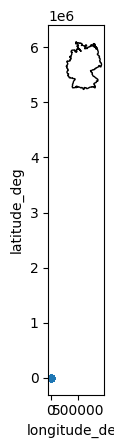

```python
# let's plot

base = Germany_25832.plot(color='white', edgecolor='black') #unprojected

infoairports.plot.scatter(x = 'longitude_deg', y = 'latitude_deg',ax=base)
```

Why is it wrong?

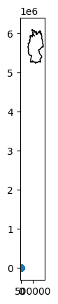

```python
airports=gpd.GeoDataFrame(data=infoairports.copy(),
                 geometry=gpd.points_from_xy(infoairports.longitude_deg,
                                             infoairports.latitude_deg),
                 crs=Germany.crs.to_epsg())# the coordinates were in degrees - unprojected

# let's plot

base = Germany_25832.plot(color='white', edgecolor='black')
airports.plot(ax=base)
```

```python
#remember:
type(airports), type(infoairports)
```

```
(geopandas.geodataframe.GeoDataFrame, pandas.core.frame.DataFrame)
```

Let's re project!

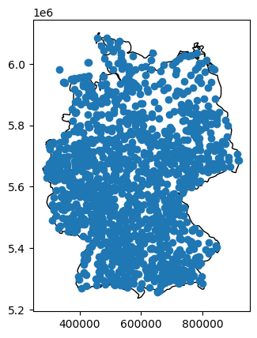

```python
airports_25832=airports.to_crs(25832)

## then

base = Germany_25832.plot(color='white', edgecolor='black')
airports_25832.plot(ax=base)
```

Remember you have type of airports:

```python
airports_25832['type'].value_counts() # this will not work: airports.type.value_counts()
```

| type | count |
| --- | --- |
| small_airport | 768 |
| heliport | 450 |
| closed | 105 |
| medium_airport | 62 |
| large_airport | 10 |
| balloonport | 2 |
| seaplane_base | 1 |

**dtype:** int64

We may use that in the future. For now, just rename the **type** column to a different one.

```python
airports_25832.rename(columns={'type':'kind'},inplace=True)

## adding the airports to GPKG
airports_25832.to_file(os.path.join("maps","GermanylMaps_25832.gpkg"), layer='airports', driver="GPKG")
```

### Exercise 2

1. Find the airports for your country [here](https://ourairports.com/data/). The data is in a CSV file.
2. Create projected layer of airports.
3. Plot all the layers and airports on top.

## Formating Geoseries projections

```python
Germany_25832
```

|  | COUNTRY | geometry |
| --- | --- | --- |
| 87 | Germany | MULTIPOLYGON (((381111.532 5447498.749, 380707... |

Sometime, you just need the border (lines):

```python
Germany_25832.boundary
```

|  | 0 |
| --- | --- |
| 87 | MULTILINESTRING ((381111.532 5447498.749, 3807... |

**dtype:** geometry

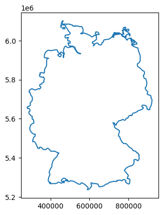

```python
# This is just the borderline
Germany_25832.boundary.plot()
```

Always check the data type:

```python
# does 'boundary' return a GDF?
type(Germany_25832.boundary)
```

```
geopandas.geoseries.GeoSeries
def __init__(data=None, index=None, crs: Optional[Any]=None, **kwargs)
```

[output not shown]

[output cut: 18 more lines]

[output not shown]

Some operations in geopandas require GDF or GS. If you need a GDF instead of a GS:

```python
# converting into GDF
Germany_25832.boundary.to_frame()
```

|  | 0 |
| --- | --- |
| 87 | MULTILINESTRING ((381111.532 5447498.749, 3807... |

```python
Germany_25832.boundary.to_frame().info()
```

```
<class 'geopandas.geodataframe.GeoDataFrame'>
Index: 1 entries, 87 to 87
Data columns (total 1 columns):
 #   Column  Non-Null Count  Dtype
---  ------  --------------  -----
 0   0       1 non-null      geometry
dtypes: geometry(1)
memory usage: 16.0 bytes
```

Notice you get a very simple GDF, and you may want to add some information:

```python
# conversion
Germany_border=Germany_25832.boundary.to_frame()

# new column (optional)
Germany_border['name']='Germany'

# renaming the geometry column
Germany_border.rename(columns={0:'geometry'},inplace=True)

#setting the geometry (the name is not enough)
Germany_border = Germany_border.set_geometry("geometry")

# verifying:
Germany_border.crs
```

```
<Projected CRS: EPSG:25832>
Name: ETRS89 / UTM zone 32N
Axis Info [cartesian]:
- E[east]: Easting (metre)
- N[north]: Northing (metre)
Area of Use:
- name: Europe between 6°E and 12°E: Austria; Denmark - onshore and offshore; Germany - onshore and offshore; Italy - onshore and offshore; Norway including Svalbard - onshore and offshore; Spain - offshore.
- bounds: (6.0, 36.53, 12.01, 84.01)
Coordinate Operation:
- name: UTM zone 32N
- method: Transverse Mercator
Datum: European Terrestrial Reference System 1989 ensemble
- Ellipsoid: GRS 1980
- Prime Meridian: Greenwich
```

```python
Germany_border
```

|  | geometry | name |
| --- | --- | --- |
| 87 | MULTILINESTRING ((381111.532 5447498.749, 3807... | Germany |

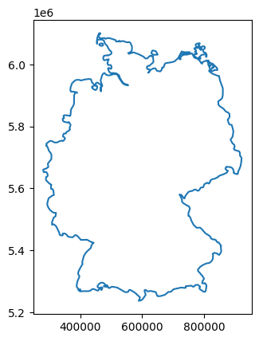

```python
# Tenemos nuestra frontera
Germany_border.plot()
```

You can add this GDF as a layer.

### Exercise 3

1. Check if your country is a polygon or multipolygon.
2. Recover just the boundaries of that country.
3. Turn the boundary into a GDF.

## Maps Lacking CRS information

Reprojecting seems a simple process, but you might find some interesting cases.

Let's read the maps on *states*(adm1) and *municipalities* (adm2):

```python
import geopandas as gpd

# Use the raw URLs for the shapefiles
Germany_states_url = 'https://raw.githubusercontent.com/nuriacasana/introgeodf/main/gadm41_DEU_shp/gadm41_DEU_1.shp'
Germany_municipalities_url = 'https://raw.githubusercontent.com/nuriacasana/introgeodf/main/gadm41_DEU_shp/gadm41_DEU_2.shp'

Germany_states = gpd.read_file(Germany_states_url)
Germany_municipalities = gpd.read_file(Germany_municipalities_url)
```

```python
Germany_states.crs, Germany_municipalities.crs
```

```
(<Geographic 2D CRS: EPSG:4326>
 Name: WGS 84
 Axis Info [ellipsoidal]:
 - Lat[north]: Geodetic latitude (degree)
 - Lon[east]: Geodetic longitude (degree)
 Area of Use:
 - name: World.
 - bounds: (-180.0, -90.0, 180.0, 90.0)
 Datum: World Geodetic System 1984 ensemble
 - Ellipsoid: WGS 84
 - Prime Meridian: Greenwich,
 <Geographic 2D CRS: EPSG:4326>
 Name: WGS 84
 Axis Info [ellipsoidal]:
 - Lat[north]: Geodetic latitude (degree)
 - Lon[east]: Geodetic longitude (degree)
 Area of Use:
 - name: World.
 - bounds: (-180.0, -90.0, 180.0, 90.0)
 Datum: World Geodetic System 1984 ensemble
 - Ellipsoid: WGS 84
 - Prime Meridian: Greenwich)
```

They are maps, for sure:

```python
type(Germany_states), type(Germany_municipalities)
```

```
(geopandas.geodataframe.GeoDataFrame, geopandas.geodataframe.GeoDataFrame)
```

```python
Germany_states.geometry.head()
```

|  | geometry |
| --- | --- |
| 0 | MULTIPOLYGON (((8.35002 47.57062, 8.34778 47.5... |
| 1 | POLYGON ((11.41009 47.4954, 11.41005 47.49536,... |
| 2 | POLYGON ((13.50022 52.61379, 13.49855 52.61068... |
| 3 | MULTIPOLYGON (((13.3222 51.43674, 13.32402 51.... |
| 4 | MULTIPOLYGON (((8.67501 53.17805, 8.67532 53.1... |

**dtype:** geometry

```python
Germany_municipalities.geometry.head()
```

|  | geometry |
| --- | --- |
| 0 | POLYGON ((9.67322 48.17136, 9.6741 48.16991, 9... |
| 1 | MULTIPOLYGON (((8.11805 48.73807, 8.11372 48.7... |
| 2 | POLYGON ((9.75139 47.97439, 9.75106 47.97507, ... |
| 3 | POLYGON ((8.8512 48.53292, 8.85111 48.53247, 8... |
| 4 | POLYGON ((9.04492 47.81646, 9.04539 47.81644, ... |

**dtype:** geometry

```python
Germany_states.crs, Germany_municipalities.crs
```

```
(<Geographic 2D CRS: EPSG:4326>
 Name: WGS 84
 Axis Info [ellipsoidal]:
 - Lat[north]: Geodetic latitude (degree)
 - Lon[east]: Geodetic longitude (degree)
 Area of Use:
 - name: World.
 - bounds: (-180.0, -90.0, 180.0, 90.0)
 Datum: World Geodetic System 1984 ensemble
 - Ellipsoid: WGS 84
 - Prime Meridian: Greenwich,
 <Geographic 2D CRS: EPSG:4326>
 Name: WGS 84
 Axis Info [ellipsoidal]:
 - Lat[north]: Geodetic latitude (degree)
 - Lon[east]: Geodetic longitude (degree)
 Area of Use:
 - name: World.
 - bounds: (-180.0, -90.0, 180.0, 90.0)
 Datum: World Geodetic System 1984 ensemble
 - Ellipsoid: WGS 84
 - Prime Meridian: Greenwich)
```

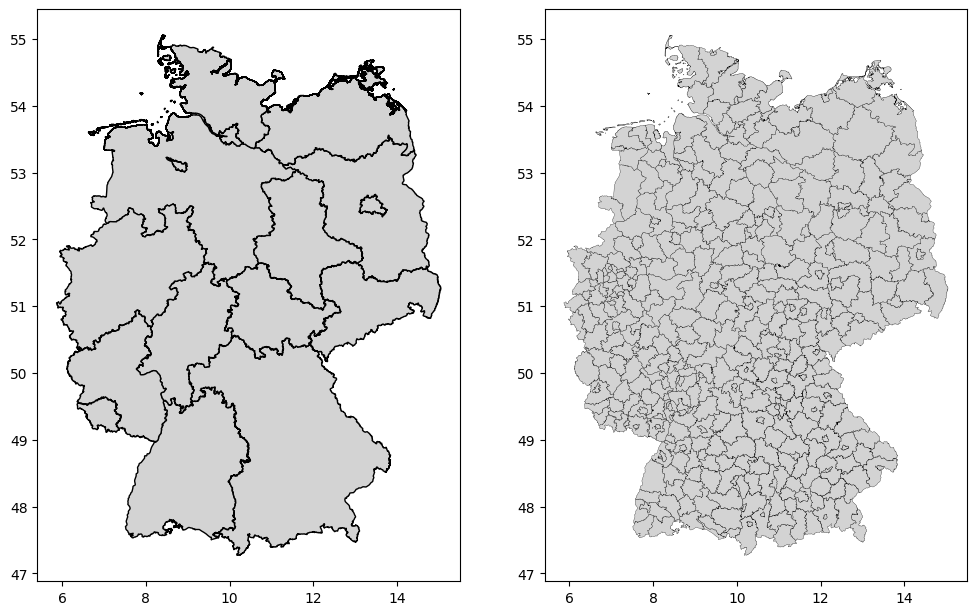

```python
import matplotlib.pyplot as plt

fig, (ax1, ax2) = plt.subplots(ncols=2, sharex=False, sharey=False, figsize=(12,12))

Germany_states.plot(ax=ax1, facecolor='lightgrey', edgecolor='black')
Germany_municipalities.plot(ax=ax2, facecolor='lightgrey', edgecolor='black',linewidth=0.2)
```

```python
## uncomment this to see the error message
# brazil_states.to_crs(5641)
```

```python
Germany_states.to_crs(25832)
```

|  | GID_1 | GID_0 | COUNTRY | NAME_1 | VARNAME_1 | NL_NAME_1 | TYPE_1 | ENGTYPE_1 | CC_1 | HASC_1 | ISO_1 | geometry |
| --- | --- | --- | --- | --- | --- | --- | --- | --- | --- | --- | --- | --- |
| 0 | DEU.1_1 | DEU | Germany | Baden-Württemberg | NA | NA | Land | State | 08 | DE.BW | NA | MULTIPOLYGON (((451113.651 5268782.63, 450945.... |
| 1 | DEU.2_1 | DEU | Germany | Bayern | Bavaria | NA | Freistaat | Free State | 09 | DE.BY | DE-BY | POLYGON ((681523.301 5263034.421, 681520.383 5... |
| 2 | DEU.3_1 | DEU | Germany | Berlin | NA | NA | Land | State | 11 | DE.BE | DE-BE | POLYGON ((804617.008 5838823.273, 804525.443 5... |
| 3 | DEU.4_1 | DEU | Germany | Brandenburg | NA | NA | Land | State | 12 | DE.BR | DE-BB | MULTIPOLYGON (((800367.2 5707259.66, 800507.47... |
| 4 | DEU.5_1 | DEU | Germany | Bremen | NA | NA | Freie Hansestadt | State | 04 | DE.HB | DE-HB | MULTIPOLYGON (((478279.797 5892126.842, 478299... |
| 5 | DEU.6_1 | DEU | Germany | Hamburg | NA | NA | Freie und Hansestadt | State | 02 | DE.HH | DE-HH | MULTIPOLYGON (((577600.604 5952022.104, 577592... |
| 6 | DEU.7_1 | DEU | Germany | Hessen | Hesse | NA | Land | State | 06 | DE.HE | DE-HE | MULTIPOLYGON (((491741.381 5473817.891, 491692... |
| 7 | DEU.8_1 | DEU | Germany | Mecklenburg-Vorpommern | Mecklenburg-West Pomerania | NA | Land | State | 13 | DE.MV | DE-MV | MULTIPOLYGON (((671745.378 5894020.782, 671752... |
| 8 | DEU.9_1 | DEU | Germany | Niedersachsen | Lower Saxony | NA | Land | State | 03 | DE.NI | DE-NI | MULTIPOLYGON (((594820.493 5712449.818, 594872... |
| 9 | DEU.10_1 | DEU | Germany | Nordrhein-Westfalen | North Rhine-Westphalia | NA | Land | State | 05 | DE.NW | DE-NW | POLYGON ((327904.444 5583358.977, 327590.502 5... |
| 10 | DEU.11_1 | DEU | Germany | Rheinland-Pfalz | Rhineland-Palatinate | NA | Land | State | 07 | DE.RP | DE-RP | POLYGON ((400714.258 5434215.464, 400298.456 5... |
| 11 | DEU.12_1 | DEU | Germany | Saarland | NA | NA | Land | State | 10 | DE.SL | DE-SL | POLYGON ((368462.592 5442239.119, 368445.68 54... |
| 12 | DEU.14_1 | DEU | Germany | Sachsen | Saxony | NA | Freistaat | State | 14 | DE.SN | DE-SN | POLYGON ((739157.149 5571586.546, 739187.972 5... |
| 13 | DEU.13_1 | DEU | Germany | Sachsen-Anhalt | Saxony-Anhalt | NA | Land | State | 15 | DE.ST | DE-ST | MULTIPOLYGON (((727539.566 5650610.982, 727584... |
| 14 | DEU.15_1 | DEU | Germany | Schleswig-Holstein | NA | NA | Land | State | 01 | DE.SH | DE-SH | MULTIPOLYGON (((600521.566 5914725.365, 600246... |
| 15 | DEU.16_1 | DEU | Germany | Thüringen | Thuringia | NA | Freistaat | State | 16 | DE.TH | NA | POLYGON ((660568.4 5571132.646, 660572.314 557... |

```python
# set as unprojected
Germany_states.crs = "EPSG:25832"
Germany_municipalities.crs = "EPSG:25832"
```

Now, we can reproject:

```python
Germany_states=Germany_states.to_crs(25832)
Germany_municipalities=Germany_municipalities.to_crs(25832)
```

```python
Germany_states.to_file(os.path.join("maps","germanyMaps_25832.gpkg"), layer='states', driver="GPKG")
Germany_municipalities.to_file(os.path.join("maps","germanyMaps_25832.gpkg"), layer='municipalities', driver="GPKG")
```

### Exercise 4

1. Look for sub administrative divisions of your country
2. Check all the CRSs of those divisions
3. If you find one CRS is missing, fill the CRS with the right projection. If not, just state nothing is to be done.

## Geo Merging

The countries map has no interesting information beyond the geometry.

```python
countries.head()
```

|  | COUNTRY | geometry |
| --- | --- | --- |
| 0 | Aruba (Netherlands) | POLYGON ((-69.88223 12.41111, -69.94695 12.436... |
| 1 | Antigua and Barbuda | MULTIPOLYGON (((-61.73889 17.54055, -61.75195 ... |
| 2 | Afghanistan | POLYGON ((61.27656 35.60725, 61.29638 35.62853... |
| 3 | Algeria | POLYGON ((-5.15213 30.18047, -5.13917 30.19236... |
| 4 | Azerbaijan | MULTIPOLYGON (((46.54037 38.87559, 46.49554 38... |

Let add some information to each country:

```python
import pandas as pd

fragilityCiaLink="https://github.com/CienciaDeDatosEspacial/merging/raw/main/FragilityCia_isos.csv"

fragilityCia=pd.read_csv(fragilityCiaLink)
# case
countries['COUNTRY']=countries.COUNTRY.str.upper()
fragilityCia.head()
```

|  | Country | Officialstatename | InternetccTLD | iso2 | iso3 | fragility | co2 | region | ForestRev_gdp |
| --- | --- | --- | --- | --- | --- | --- | --- | --- | --- |
| 0 | AFGHANISTAN | The Islamic Republic of Afghanistan | .af | AF | AFG | 105.0 | 7893000.0 | SOUTH ASIA | 0.20 |
| 1 | ALBANIA | The Republic of Albania | .al | AL | ALB | 58.9 | 3794000.0 | EUROPE | 0.18 |
| 2 | ALGERIA | The People's Democratic Republic of Algeria | .dz | DZ | DZA | 75.4 | 151633000.0 | AFRICA | 0.10 |
| 3 | ANGOLA | The Republic of Angola | .ao | AO | AGO | 87.8 | 19362000.0 | AFRICA | 0.36 |
| 4 | ANTIGUA AND BARBUDA | Antigua and Barbuda | .ag | AG | ATG | 54.4 | 729000.0 | CENTRAL AMERICA AND THE CARIBBEAN | 0.00 |

We want to add the *fragilityCia* data into the map. That is the merging process. For that, we need a common column. The *Country* column is the option.

```python
# to upper case.
countries['COUNTRY']=countries.COUNTRY.str.upper()
```

It is very unlikely the names are written the same. Verify:

```python
onlyFragilCia=set(fragilityCia.Country)- set(countries.COUNTRY)
onlyMap=set(countries.COUNTRY)- set(fragilityCia.Country)
```

Check here:

```python
onlyFragilCia
```

```
{'BAHAMAS (THE)',
 'BOLIVIA (PLURINATIONAL STATE OF)',
 'BRUNEI DARUSSALAM',
 'CABO VERDE',
 'CENTRAL AFRICAN REPUBLIC (THE)',
 'COMOROS (THE)',
 'CONGO (THE DEMOCRATIC REPUBLIC OF THE)',
 'CONGO (THE)',
 "CÔTE D'IVOIRE",
 'DOMINICAN REPUBLIC (THE)',
 'ESWATINI',
 'GAMBIA (THE)',
 'IRAN (ISLAMIC REPUBLIC OF)',
 'KOREA (THE REPUBLIC OF)',
 "LAO PEOPLE'S DEMOCRATIC REPUBLIC (THE)",
 'MICRONESIA (FEDERATED STATES OF)',
 'MOLDOVA (THE REPUBLIC OF)',
 'NETHERLANDS (THE)',
 'NIGER (THE)',
 'NORTH MACEDONIA',
 'NORTHERN MARIANA ISLANDS (THE)',
 'PHILIPPINES (THE)',
 'RUSSIAN FEDERATION (THE)',
 'SAMOA',
 'SUDAN (THE)',
 'TANZANIA, THE UNITED REPUBLIC OF',
 'TIMOR-LESTE',
 'UNITED ARAB EMIRATES (THE)',
 'UNITED KINGDOM OF GREAT BRITAIN AND NORTHERN IRELAND (THE)',
 'UNITED STATES OF AMERICA (THE)',
 'VIET NAM'}
```

```python
# and here
onlyMap
```

```
{'AMERICAN SAMOA (US)',
 'AMERICAN VIRGIN ISLANDS (US)',
 'ANDORRA',
 'ANGUILLA (UK)',
 'ANTARCTICA',
 'ARUBA (NETHERLANDS)',
 'BAHAMAS',
 'BAKER ISLAND (US)',
 'BERMUDA (UK)',
 'BOLIVIA',
 'BONAIRE (NETHERLANDS)',
 'BOUVET ISLAND (NORWAY)',
 'BRITISH INDIAN OCEAN TERRITORY (UK)',
 'BRITISH VIRGIN ISLANDS(UK)',
 'BRUNEI',
 'CAPE VERDE',
 'CAYMAN ISLANDS (UK)',
 'CENTRAL AFRICAN REPUBLIC',
 'CHRISTMAS ISLAND (AUSTRALIA)',
 'COCOS (KEELING) ISLANDS (AUSTRALIA)',
 'COMOROS',
 'CONGO',
 'COOK ISLANDS (NEW ZEALAND)',
 'CURACAO (NETHERLANDS)',
 'CZECH REPUBLIC',
 'DEMOCRATIC REPUBLIC OF THE CONGO',
 'DOMINICA',
 'DOMINICAN REPUBLIC',
 'EAST TIMOR',
 'ERITREA',
 'FALKLAND ISLANDS (UK)',
 'FAROE ISLANDS (DENMARK)',
 'FEDERATED STATES OF MICRONESIA',
 'FRENCH GUIANA (FRANCE)',
 'FRENCH POLYNESIA (FRANCE)',
 'FRENCH SOUTHERN & ANTARCTIC LANDS (FRANCE)',
 'GAMBIA',
 'GIBRALTAR (UK)',
 'GLORIOSO ISLANDS (FRANCE)',
 'GREENLAND (DENMARK)',
```

[output cut: 58 more lines]

```
 'TANZANIA',
 'TOKELAU (NEW ZEALAND)',
 'TONGA',
 'TURKS AND CAICOS ISLANDS (UK)',
 'TUVALU',
 'UNITED ARAB EMIRATES',
 'UNITED KINGDOM',
 'UNITED STATES',
 'VANUATU',
 'VENEZUELA',
 'VIETNAM',
 'WAKE ISLAND (US)',
 'WALLIS AND FUTUNA (FRANCE)',
 'WESTERN SAHARA',
 'WESTERN SAMOA'}
```

## Fuzzy merging

Let's find similar names:

```python
# !pip install thefuzz
```

```python
!pip install thefuzz
```

```
Downloading thefuzz-0.22.1-py3-none-any.whl (8.2 kB)
Downloading rapidfuzz-3.13.0-cp311-cp311-manylinux_2_17_x86_64.manylinux2014_x86_64.whl (3.1 MB)
   ━━━━━━━━━━━━━━━━━━━━━━━━━━━━━━━━━━━━━━━━ 3.1/3.1 MB 27.1 MB/s eta 0:00:00
```

```python
from thefuzz import process

[(country, process.extractOne(country,onlyMap)) for country in sorted(onlyFragilCia)]
```

```
[('BAHAMAS (THE)', ('BAHAMAS', 90)),
 ('BOLIVIA (PLURINATIONAL STATE OF)', ('BOLIVIA', 90)),
 ('BRUNEI DARUSSALAM', ('BRUNEI', 90)),
 ('CABO VERDE', ('CAPE VERDE', 80)),
 ('CENTRAL AFRICAN REPUBLIC (THE)', ('CENTRAL AFRICAN REPUBLIC', 95)),
 ('COMOROS (THE)', ('COMOROS', 90)),
 ('CONGO (THE DEMOCRATIC REPUBLIC OF THE)',
  ('DEMOCRATIC REPUBLIC OF THE CONGO', 95)),
 ('CONGO (THE)', ('CONGO', 90)),
 ("CÔTE D'IVOIRE", ('IVORY COAST', 58)),
 ('DOMINICAN REPUBLIC (THE)', ('DOMINICAN REPUBLIC', 95)),
 ('ESWATINI', ('MARTINIQUE (FRANCE)', 60)),
 ('GAMBIA (THE)', ('GAMBIA', 90)),
 ('IRAN (ISLAMIC REPUBLIC OF)', ('IRAN', 90)),
 ('KOREA (THE REPUBLIC OF)', ('CZECH REPUBLIC', 86)),
 ("LAO PEOPLE'S DEMOCRATIC REPUBLIC (THE)", ('CENTRAL AFRICAN REPUBLIC', 86)),
 ('MICRONESIA (FEDERATED STATES OF)', ('FEDERATED STATES OF MICRONESIA', 95)),
 ('MOLDOVA (THE REPUBLIC OF)', ('MOLDOVA', 90)),
 ('NETHERLANDS (THE)', ('NETHERLANDS', 95)),
 ('NIGER (THE)', ('NIGER', 90)),
 ('NORTH MACEDONIA', ('MACEDONIA', 90)),
 ('NORTHERN MARIANA ISLANDS (THE)', ('NORTHERN MARIANA ISLANDS (US)', 91)),
 ('PHILIPPINES (THE)', ('PHILIPPINES', 95)),
 ('RUSSIAN FEDERATION (THE)', ('RUSSIA', 90)),
 ('SAMOA', ('WESTERN SAMOA', 90)),
 ('SUDAN (THE)', ('SUDAN', 90)),
 ('TANZANIA, THE UNITED REPUBLIC OF', ('TANZANIA', 90)),
 ('TIMOR-LESTE', ('EAST TIMOR', 81)),
 ('UNITED ARAB EMIRATES (THE)', ('UNITED ARAB EMIRATES', 95)),
 ('UNITED KINGDOM OF GREAT BRITAIN AND NORTHERN IRELAND (THE)',
  ('UNITED KINGDOM', 90)),
 ('UNITED STATES OF AMERICA (THE)', ('UNITED STATES', 90)),
 ('VIET NAM', ('VIETNAM', 93))]
```

```python
# keeping high scores

[(country, process.extractOne(country,onlyMap)) for country in sorted(onlyFragilCia)
 if process.extractOne(country,onlyMap)[1]>=90]
```

```
[('BAHAMAS (THE)', ('BAHAMAS', 90)),
 ('BOLIVIA (PLURINATIONAL STATE OF)', ('BOLIVIA', 90)),
 ('BRUNEI DARUSSALAM', ('BRUNEI', 90)),
 ('CENTRAL AFRICAN REPUBLIC (THE)', ('CENTRAL AFRICAN REPUBLIC', 95)),
 ('COMOROS (THE)', ('COMOROS', 90)),
 ('CONGO (THE DEMOCRATIC REPUBLIC OF THE)',
  ('DEMOCRATIC REPUBLIC OF THE CONGO', 95)),
 ('CONGO (THE)', ('CONGO', 90)),
 ('DOMINICAN REPUBLIC (THE)', ('DOMINICAN REPUBLIC', 95)),
 ('GAMBIA (THE)', ('GAMBIA', 90)),
 ('IRAN (ISLAMIC REPUBLIC OF)', ('IRAN', 90)),
 ('MICRONESIA (FEDERATED STATES OF)', ('FEDERATED STATES OF MICRONESIA', 95)),
 ('MOLDOVA (THE REPUBLIC OF)', ('MOLDOVA', 90)),
 ('NETHERLANDS (THE)', ('NETHERLANDS', 95)),
 ('NIGER (THE)', ('NIGER', 90)),
 ('NORTH MACEDONIA', ('MACEDONIA', 90)),
 ('NORTHERN MARIANA ISLANDS (THE)', ('NORTHERN MARIANA ISLANDS (US)', 91)),
 ('PHILIPPINES (THE)', ('PHILIPPINES', 95)),
 ('RUSSIAN FEDERATION (THE)', ('RUSSIA', 90)),
 ('SAMOA', ('WESTERN SAMOA', 90)),
 ('SUDAN (THE)', ('SUDAN', 90)),
 ('TANZANIA, THE UNITED REPUBLIC OF', ('TANZANIA', 90)),
 ('UNITED ARAB EMIRATES (THE)', ('UNITED ARAB EMIRATES', 95)),
 ('UNITED KINGDOM OF GREAT BRITAIN AND NORTHERN IRELAND (THE)',
  ('UNITED KINGDOM', 90)),
 ('UNITED STATES OF AMERICA (THE)', ('UNITED STATES', 90)),
 ('VIET NAM', ('VIETNAM', 93))]
```

Preparing a *dict* of changes:

```python
# then:
try1={country: process.extractOne(country,onlyMap)[0] for country in sorted(onlyFragilCia)
 if process.extractOne(country,onlyMap)[1]>=90}
try1
```

```
{'BAHAMAS (THE)': 'BAHAMAS',
 'BOLIVIA (PLURINATIONAL STATE OF)': 'BOLIVIA',
 'BRUNEI DARUSSALAM': 'BRUNEI',
 'CENTRAL AFRICAN REPUBLIC (THE)': 'CENTRAL AFRICAN REPUBLIC',
 'COMOROS (THE)': 'COMOROS',
 'CONGO (THE DEMOCRATIC REPUBLIC OF THE)': 'DEMOCRATIC REPUBLIC OF THE CONGO',
 'CONGO (THE)': 'CONGO',
 'DOMINICAN REPUBLIC (THE)': 'DOMINICAN REPUBLIC',
 'GAMBIA (THE)': 'GAMBIA',
 'IRAN (ISLAMIC REPUBLIC OF)': 'IRAN',
 'MICRONESIA (FEDERATED STATES OF)': 'FEDERATED STATES OF MICRONESIA',
 'MOLDOVA (THE REPUBLIC OF)': 'MOLDOVA',
 'NETHERLANDS (THE)': 'NETHERLANDS',
 'NIGER (THE)': 'NIGER',
 'NORTH MACEDONIA': 'MACEDONIA',
 'NORTHERN MARIANA ISLANDS (THE)': 'NORTHERN MARIANA ISLANDS (US)',
 'PHILIPPINES (THE)': 'PHILIPPINES',
 'RUSSIAN FEDERATION (THE)': 'RUSSIA',
 'SAMOA': 'WESTERN SAMOA',
 'SUDAN (THE)': 'SUDAN',
 'TANZANIA, THE UNITED REPUBLIC OF': 'TANZANIA',
 'UNITED ARAB EMIRATES (THE)': 'UNITED ARAB EMIRATES',
 'UNITED KINGDOM OF GREAT BRITAIN AND NORTHERN IRELAND (THE)': 'UNITED KINGDOM',
 'UNITED STATES OF AMERICA (THE)': 'UNITED STATES',
 'VIET NAM': 'VIETNAM'}
```

Making changes and updating:

```python
fragilityCia.replace(to_replace={'Country':try1},inplace=True)

# updating
onlyFragilCia=set(fragilityCia.Country)- set(countries.COUNTRY)
onlyMap=set(countries.COUNTRY)- set(fragilityCia.Country)
# new matches
[(country, process.extractOne(country,onlyMap)) for country in sorted(onlyFragilCia)]
```

```
[('CABO VERDE', ('CAPE VERDE', 80)),
 ("CÔTE D'IVOIRE", ('IVORY COAST', 58)),
 ('ESWATINI', ('MARTINIQUE (FRANCE)', 60)),
 ('KOREA (THE REPUBLIC OF)', ('CZECH REPUBLIC', 86)),
 ("LAO PEOPLE'S DEMOCRATIC REPUBLIC (THE)", ('CZECH REPUBLIC', 86)),
 ('TIMOR-LESTE', ('EAST TIMOR', 81))]
```

```python
# some manual

countries[countries.COUNTRY.str.contains('LAO|SWA|KOR')]
```

|  | COUNTRY | geometry |
| --- | --- | --- |
| 17 | BOTSWANA | POLYGON ((26.40114 -24.63189, 26.38996 -24.627... |
| 120 | NORTH KOREA | POLYGON ((125.62979 38.65694, 125.51721 38.717... |
| 122 | SOUTH KOREA | MULTIPOLYGON (((126.86922 36.0606, 126.8591 36... |
| 126 | LAOS | POLYGON ((104.257 17.88763, 104.23943 17.93722... |
| 243 | SWAZILAND | POLYGON ((30.89944 -26.77195, 30.88028 -26.793... |

```python
manualChanges={'SWAZILAND':'ESWATINI','LAOS':"LAO PEOPLE'S DEMOCRATIC REPUBLIC (THE)",'SOUTH KOREA':'KOREA (THE REPUBLIC OF)'}

countries.replace(to_replace={'COUNTRY':manualChanges},inplace=True)

# updating
onlyFragilCia=set(fragilityCia.Country)- set(countries.COUNTRY)
onlyMap=set(countries.COUNTRY)- set(fragilityCia.Country)
# new matches
[(country, process.extractOne(country,onlyMap)) for country in sorted(onlyFragilCia)]
```

```
[('CABO VERDE', ('CAPE VERDE', 80)),
 ("CÔTE D'IVOIRE", ('IVORY COAST', 58)),
 ('TIMOR-LESTE', ('EAST TIMOR', 81))]
```

```python
# then:
try2={country: process.extractOne(country,onlyMap)[0] for country in sorted(onlyFragilCia)}
try2
```

```
{'CABO VERDE': 'CAPE VERDE',
 "CÔTE D'IVOIRE": 'IVORY COAST',
 'TIMOR-LESTE': 'EAST TIMOR'}
```

```python
# changing
fragilityCia.replace(to_replace={'Country':try2},inplace=True)

# new update
onlyFragilCia=set(fragilityCia.Country)- set(countries.COUNTRY)
onlyMap=set(countries.COUNTRY)- set(fragilityCia.Country)

# new matches
[(country, process.extractOne(country,onlyMap)) for country in sorted(onlyFragilCia)]
```

```
[]
```

We can not improve the situation.

Now, when you merge a GDF with a DF, **the GDF has to be on the left**:

```python
theMapAndData=countries.merge(fragilityCia,left_on='COUNTRY', right_on='Country')

theMapAndData.drop(columns=['Country'],inplace=True) # no need for this column
# here it is (new map):
theMapAndData.info()
```

```
<class 'geopandas.geodataframe.GeoDataFrame'>
RangeIndex: 170 entries, 0 to 169
Data columns (total 10 columns):
 #   Column             Non-Null Count  Dtype
---  ------             --------------  -----
 0   COUNTRY            170 non-null    object
 1   geometry           170 non-null    geometry
 2   Officialstatename  170 non-null    object
 3   InternetccTLD      170 non-null    object
 4   iso2               169 non-null    object
 5   iso3               170 non-null    object
 6   fragility          170 non-null    float64
 7   co2                170 non-null    float64
 8   region             170 non-null    object
 9   ForestRev_gdp      170 non-null    float64
dtypes: float64(3), geometry(1), object(6)
memory usage: 13.4+ KB
```

# Choropleths

## Transformation of data values

### Re Scaling

We should plan how to color the polygons based on some variable, let me check our variables of interest:

```python
DataNames=[ 'co2', 'ForestRev_gdp']
```

```python
pd.melt(theMapAndData[DataNames])
```

|  | variable | value |
| --- | --- | --- |
| 0 | co2 | 7.290000e+05 |
| 1 | co2 | 7.893000e+06 |
| 2 | co2 | 1.516330e+08 |
| 3 | co2 | 3.538900e+07 |
| 4 | co2 | 3.794000e+06 |
| ... | ... | ... |
| 335 | ForestRev_gdp | 4.450000e+00 |
| 336 | ForestRev_gdp | 1.610000e+00 |
| 337 | ForestRev_gdp | 2.650000e+00 |
| 338 | ForestRev_gdp | 3.900000e-01 |
| 339 | ForestRev_gdp | 1.300000e-01 |

340 rows × 2 columns

```python
!pip install seaborn
```

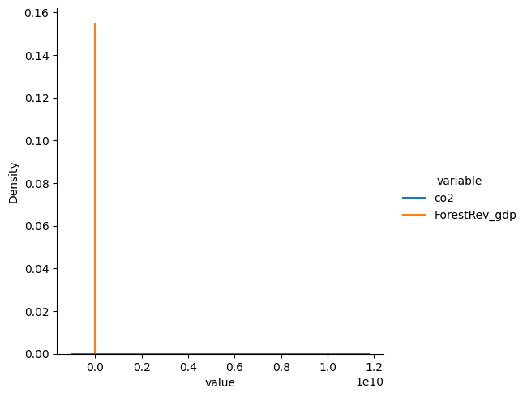

```python
import seaborn as sns
import matplotlib.pyplot as plt

sns.displot(pd.melt(theMapAndData[DataNames]),
            x="value", hue="variable",kind="kde",
            log_scale=(False,False))
```

The variables are in different units, we should try a data rescaling strategy:

```python
!pip install -U scikit-learn
```

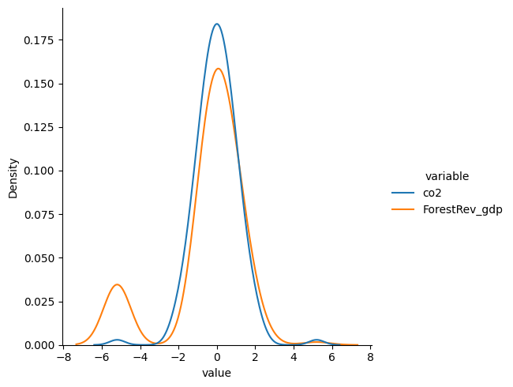

```python
from sklearn.preprocessing import QuantileTransformer
scaler = QuantileTransformer(n_quantiles=99, random_state=0,output_distribution='normal') #or 'uniform'
QtScaled_data = scaler.fit_transform(theMapAndData[DataNames])

sns.displot(pd.melt(pd.DataFrame(QtScaled_data,columns=DataNames)),
            x="value", hue="variable",kind="kde",
            log_scale=(False,False))
```

```python
theMapAndData['co2_Qt']=QtScaled_data[:,0]
```

```python
! pip show numba mapclassify numpy
```

[output not shown]

[output cut: 932 more lines]

[output not shown]

```python
!pip install mapclassify
```

```
Downloading mapclassify-2.9.0-py3-none-any.whl (286 kB)
   ━━━━━━━━━━━━━━━━━━━━━━━━━━━━━━━━━━━━━━━━ 286.7/286.7 kB 4.1 MB/s eta 0:00:00
```

- **MinMaxScaler**:

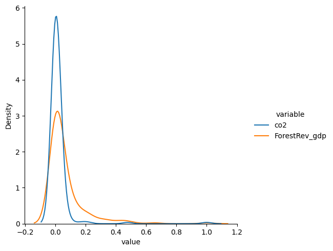

```python
from sklearn.preprocessing import MinMaxScaler

scaler = MinMaxScaler(feature_range=(0, 1))
scaled_data=scaler.fit_transform(theMapAndData[DataNames])

sns.displot(pd.melt(pd.DataFrame(scaled_data,columns=DataNames)),
            x="value", hue="variable",kind="kde",
            log_scale=(False,False))
```

- **RobustScaler**:

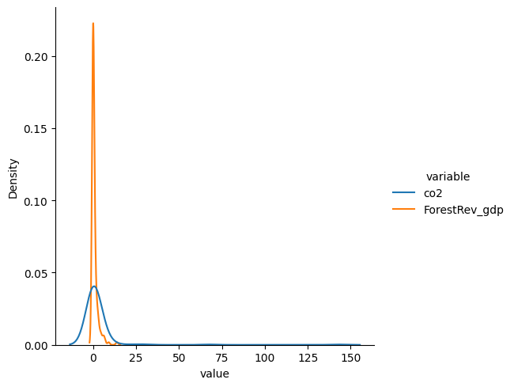

```python
from sklearn.preprocessing import RobustScaler
scaler = RobustScaler()
robScaled_data = scaler.fit_transform(theMapAndData[DataNames])

sns.displot(pd.melt(pd.DataFrame(robScaled_data,columns=DataNames)),
            x="value", hue="variable",kind="kde",
            log_scale=(False,False))
```

- **QuantileTransformer**:

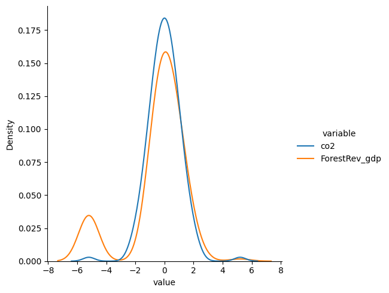

```python
from sklearn.preprocessing import QuantileTransformer
scaler = QuantileTransformer(n_quantiles=99, random_state=0,output_distribution='normal') #or 'uniform'
QtScaled_data = scaler.fit_transform(theMapAndData[DataNames])

sns.displot(pd.melt(pd.DataFrame(QtScaled_data,columns=DataNames)),
            x="value", hue="variable",kind="kde",
            log_scale=(False,False))
```

Let's keep the last one:

```python
theMapAndData['co2_Qt']=QtScaled_data[:,0]
```